# Caret package

Oleksii Yehorchenkov

30 11 2020

This tutorial is based on Coursera course [Practical Machine Learning](https://www.coursera.org/learn/practical-machine-learning/home/welcome) And [Introduction to Data Science](https://rafalab.github.io/dsbook/) by Rafael A. Irizarry

# The Caret R Package

http://topepo.github.io/caret/index.html

## Caret functionality

- Some preprocessing (cleaning)
  - preProcess
- Data splitting
  - createDataPartition
  - createResample
  - createTimeSlices
- Training/testing functions
  - train
  - predict
- Model comparison
  - confusionMatrix

## Machine learning algorithms in R

- Linear discriminant analysis
- Regression
- Naive Bayes
- Support vector machines
- Classification and regression trees
- Random forests
- Boosting
- etc.

## SPAM Example: Data splitting

```r
library(caret); library(kernlab); data(spam)
inTrain <- createDataPartition(y=spam$type,
                              p=0.75, list=FALSE)
training <- spam[inTrain,]
testing <- spam[-inTrain,]
dim(training); dim(testing)
```

```
## [1] 3451   58
```

```
## [1] 1150   58
```

## SPAM Example: Fit a model

```r
set.seed(32343)
modelFit <- train(type ~.,data=training, method="glm")
modelFit
```

```
## Generalized Linear Model
##
## 3451 samples
##   57 predictor
##    2 classes: 'nonspam', 'spam'
##
## No pre-processing
## Resampling: Bootstrapped (25 reps)
## Summary of sample sizes: 3451, 3451, 3451, 3451, 3451, 3451, ...
## Resampling results:
##
##   Accuracy   Kappa
##   0.9240395  0.8405348
```

## SPAM Example: Final model

```r
modelFit <- train(type ~.,data=training, method="glm")
modelFit$finalModel
```

```
##
## Call:  NULL
##
## Coefficients:
##       (Intercept)               make            address                all
##        -1.692e+00         -3.127e-01         -1.181e-01          1.075e-01
##             num3d                our               over             remove
##         2.858e+00          4.842e-01          6.740e-01          1.861e+00
##          internet              order               mail            receive
##         5.243e-01          9.187e-01          1.477e-01          3.771e-02
##              will             people             report          addresses
##        -2.003e-01         -1.131e-01          1.433e-01          1.140e+00
##              free           business              email                you
##         8.946e-01          9.488e-01          1.254e-01          5.830e-02
##            credit               your               font             num000
##         1.223e+00          2.367e-01          1.863e-01          2.697e+00
##             money                 hp                hpl             george
##         8.358e-01         -1.617e+00         -1.245e+00         -1.145e+01
##            num650                lab               labs             telnet
##         7.771e-01         -1.601e+00          1.025e-04          1.147e+00
##            num857               data             num415              num85
##         1.359e+00         -4.730e-01         -4.515e-01         -2.146e+00
##        technology            num1999              parts                 pm
##         7.021e-01         -1.411e-01         -5.564e-01         -7.990e-01
##            direct                 cs            meeting           original
##        -1.515e-01         -4.103e+01         -1.937e+00         -1.402e+00
##           project                 re                edu              table
##        -1.420e+00         -5.342e-01         -1.455e+00         -2.076e+00
##        conference      charSemicolon   charRoundbracket  charSquarebracket
##        -5.018e+00         -1.244e+00         -2.557e-01         -8.057e-01
##   charExclamation         charDollar           charHash         capitalAve
##         1.100e+00          5.018e+00          2.129e+00          2.308e-02
##       capitalLong       capitalTotal
##         7.068e-03          8.029e-04
##
## Degrees of Freedom: 3450 Total (i.e. Null);  3393 Residual
## Null Deviance:       4628
## Residual Deviance: 1351  AIC: 1467
```

## SPAM Example: Prediction

```r
predictions <- predict(modelFit,newdata=testing)
head(predictions, 20)
```

```
##  [1] spam    spam    spam    spam    spam    spam    spam    spam    spam
## [10] spam    spam    spam    spam    spam    spam    spam    spam    spam
## [19] spam    nonspam
## Levels: nonspam spam
```

```r
length(predictions)
```

```
## [1] 1150
```

## SPAM Example: Confusion Matrix

```r
confusionMatrix(predictions,testing$type)
```

```
## Confusion Matrix and Statistics
##
##           Reference
## Prediction nonspam spam
##    nonspam     667   46
##    spam         30  407
##
##                Accuracy : 0.9339
##                  95% CI : (0.918, 0.9476)
##     No Information Rate : 0.6061
##     P-Value [Acc > NIR] : < 2e-16
##
##                   Kappa : 0.8607
##
##  Mcnemar's Test P-Value : 0.08532
##
##             Sensitivity : 0.9570
##             Specificity : 0.8985
##          Pos Pred Value : 0.9355
##          Neg Pred Value : 0.9314
##              Prevalence : 0.6061
##          Detection Rate : 0.5800
##    Detection Prevalence : 0.6200
##       Balanced Accuracy : 0.9277
##
##        'Positive' Class : nonspam
##
```

Just accuracy metric from confusion matrix

```r
confusionMatrix(predictions,testing$type)$overall[["Accuracy"]]
```

```
## [1] 0.933913
```

# Caret options

## Train options

```
# Default S3 method:
train(
  x,
  y,
  method = "rf",
  preProcess = NULL,
  ...,
  weights = NULL,
  metric = ifelse(is.factor(y), "Accuracy", "RMSE"),
  maximize = ifelse(metric %in% c("RMSE", "logLoss", "MAE"), FALSE, TRUE),
  trControl = trainControl(),
  tuneGrid = NULL,
  tuneLength = ifelse(trControl$method == "none", 1, 3)
)
```

## Metric options

**Continous outcomes**: * *RMSE* = Root mean squared error * *RSquared* = $R^2$ from regression models

**Categorical outcomes**: * *Accuracy* = Fraction correct * *Kappa* = A measure of [concordance](http://en.wikipedia.org/wiki/Cohen%27s_kappa)

## trainControl

```r
args(trainControl)
```

```
## function (method = "boot", number = ifelse(grepl("cv", method),
##     10, 25), repeats = ifelse(grepl("[d_]cv$", method), 1, NA),
##     p = 0.75, search = "grid", initialWindow = NULL, horizon = 1,
##     fixedWindow = TRUE, skip = 0, verboseIter = FALSE, returnData = TRUE,
##     returnResamp = "final", savePredictions = FALSE, classProbs = FALSE,
##     summaryFunction = defaultSummary, selectionFunction = "best",
##     preProcOptions = list(thresh = 0.95, ICAcomp = 3, k = 5,
##         freqCut = 95/5, uniqueCut = 10, cutoff = 0.9), sampling = NULL,
##     index = NULL, indexOut = NULL, indexFinal = NULL, timingSamps = 0,
##     predictionBounds = rep(FALSE, 2), seeds = NA, adaptive = list(min = 5,
##         alpha = 0.05, method = "gls", complete = TRUE), trim = FALSE,
##     allowParallel = TRUE)
## NULL
```

## trainControl resampling

- *method*
  - *boot* = bootstrapping
  - *boot632* = bootstrapping with adjustment
  - *cv* = cross validation
  - *repeatedcv* = repeated cross validation
  - *LOOCV* = leave one out cross validation
- *number*
  - For boot/cross validation
  - Number of subsamples to take
- *repeats*
  - Number of times to repeate subsampling
  - If big this can *slow things down*

## Setting the seed

- It is often useful to set an overall seed
- You can also set a seed for each resample
- Seeding each resample is useful for parallel fits

```r
set.seed(123)
```

## train control example

When an algorithm includes a tuning parameter, train automatically uses cross validation to decide among a few default values. To find out what parameter or parameters are optimized, you can read the [manual](https://topepo.github.io/caret/available-models.html) or use a quick lookup like this:

```r
modelLookup("rpart")
```

```
##   model parameter                label forReg forClass probModel
## 1 rpart        cp Complexity Parameter   TRUE     TRUE      TRUE
```

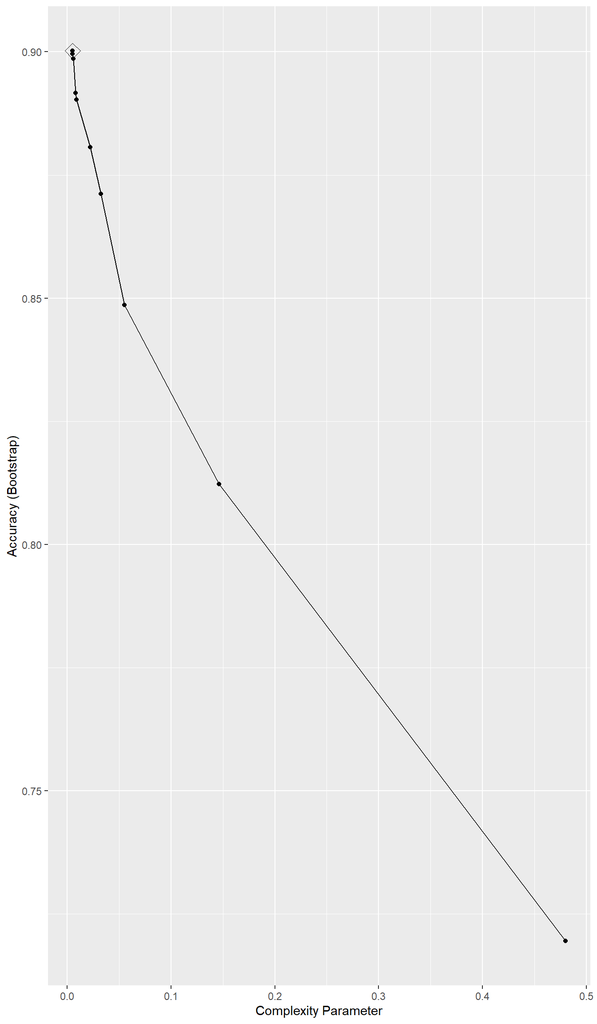

```r
train_rpart <- train(type ~ ., data = training,
                     method = "rpart",
                     tuneLength = 10)

ggplot(train_rpart, highlight = TRUE)
```

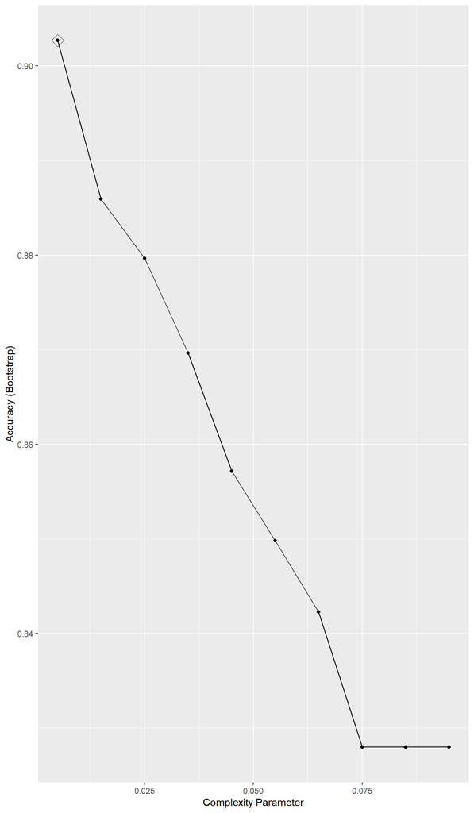

```r
train_rpart <- train(type ~ ., data = training,
                     method = "rpart",
                     tuneGrid =
                       data.frame(cp = seq(0.005, 0.1, 0.01)))

ggplot(train_rpart, highlight = TRUE)
```

If we want to change how we perform cross validation, we can use the trainControl function. We can make the code above go a bit faster by using, for example, 10-fold cross validation. This means we have 10 samples using 10% of the observations each. We accomplish this using the following code:

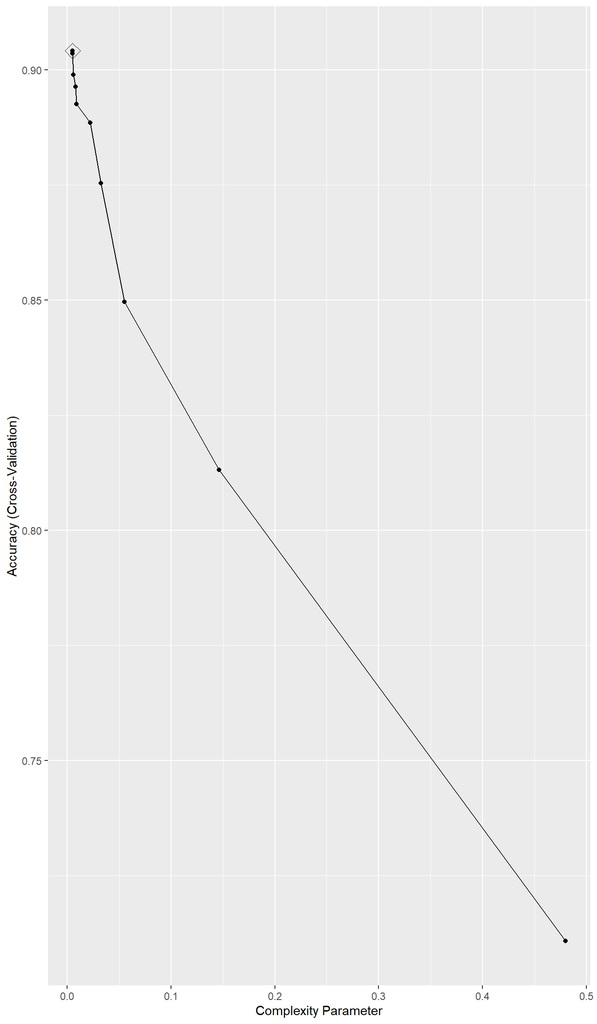

```r
control <- trainControl(method = "cv", number = 10, p = .9)

train_rpart <- train(type ~ ., data = training,
                     method = "rpart",
                     trControl = control,
                     tuneLength = 10)

ggplot(train_rpart, highlight = TRUE)
```

We can build a tree

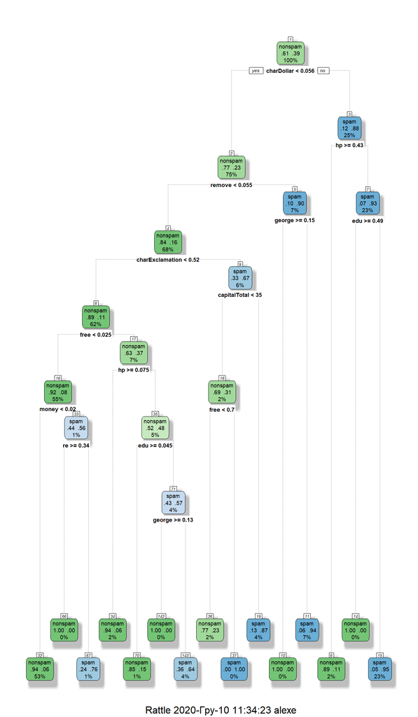

```r
library(rattle)
fancyRpartPlot(train_rpart$finalModel)
```

## Preprocessing

For basic preprocessing we can use argument `preProcess` in `train` function

```r
train_rpart <- train(type ~ ., data = training,
                     method = "rpart",
                     trControl = control,
                     preProcess = c("center","scale"))
train_rpart
```

```
## CART
##
## 3451 samples
##   57 predictor
##    2 classes: 'nonspam', 'spam'
##
## Pre-processing: centered (57), scaled (57)
## Resampling: Cross-Validated (10 fold)
## Summary of sample sizes: 3106, 3106, 3106, 3106, 3105, 3106, ...
## Resampling results across tuning parameters:
##
##   cp          Accuracy   Kappa
##   0.05514706  0.8551202  0.6887162
##   0.14632353  0.8215155  0.6051473
##   0.48014706  0.7087618  0.2996633
##
## Accuracy was used to select the optimal model using the largest value.
## The final value used for the model was cp = 0.05514706.
```

Also we can use preprocessing with PCA. We will capture 80% of variance. Default value is 95%.

```r
training_pca <- preProcess(training, method = "pca",
                           thresh = 0.8)

training_pca
```

```
## Created from 3451 samples and 58 variables
##
## Pre-processing:
##   - centered (57)
##   - ignored (1)
##   - principal component signal extraction (57)
##   - scaled (57)
##
## PCA needed 35 components to capture 80 percent of the variance
```

Instead of 57 columns we need just 35 now.

Let’s have a look on a new data

```r
head(predict(training_pca, training))
```

```
##   type       PC1        PC2         PC3         PC4         PC5        PC6
## 1 spam 0.7723234 -0.1139619  0.56243770  0.30779288 -0.19586567  0.4693534
## 2 spam 1.1918705 -2.0368736 -0.06664463 -0.36698468 -0.26888265  0.8313630
## 3 spam 1.4477803 -4.6681083 -3.16976554 -0.96160430  0.84754156  2.6312422
## 4 spam 0.8159061 -0.4318085  0.57743068 -0.05809847 -0.08981389 -0.4713702
## 5 spam 0.8165910 -0.4307423  0.57971612 -0.05847931 -0.08992428 -0.4712593
## 7 spam 1.0248690 -1.0928055  1.72615996  0.09304948  0.86705468 -1.3317099
##          PC7         PC8          PC9        PC10       PC11       PC12
## 1 -0.0292657 -0.25595791  0.231149682  0.48398008 -1.2890518 -0.2383736
## 2 -0.3713653 -0.69861596  0.710139268 -0.43058508  0.3770171  0.1319887
## 3 -2.4988010  1.83066917 -1.879801847 -0.16109069 -0.7792284 -1.0673897
## 4  0.3593985  0.53968877 -0.415082568 -0.01585551  0.2910538  0.1180299
## 5  0.3580781  0.54133916 -0.415193477 -0.01747617  0.2911842  0.1169699
## 7  0.2566459 -0.04607374 -0.004749288 -0.04821108 -0.4327970 -0.6854239
##         PC13         PC14       PC15       PC16       PC17       PC18
```

[output cut: 27 more lines]

We can use PCA preprocessing with `train` function

```r
train_rpart <- train(type ~ ., data = training,
                     method = "rpart",
                     trControl = control,
                     preProcess = "pca")
train_rpart
```

```
## CART
##
## 3451 samples
##   57 predictor
##    2 classes: 'nonspam', 'spam'
##
## Pre-processing: principal component signal extraction (57), centered
##  (57), scaled (57)
## Resampling: Cross-Validated (10 fold)
## Summary of sample sizes: 3106, 3106, 3106, 3106, 3106, 3106, ...
## Resampling results across tuning parameters:
##
##   cp          Accuracy   Kappa
##   0.05514706  0.8522116  0.6877484
##   0.14632353  0.8522116  0.6877484
##   0.48014706  0.8522116  0.6877484
##
## Accuracy was used to select the optimal model using the largest value.
## The final value used for the model was cp = 0.4801471.
```